# Лабораторна робота № 5. Дисперсійний аналіз (ANOVA)

Author

Озівський Владислав

Published

5 грудня 2025 р.

## 1. Постановка завдання

**Мета роботи:** Продемонструвати сутність однофакторного дисперсійного аналізу під час обробки експериментальних даних, набути навичок практичного застосування однофакторного дисперсійного аналізу (Сидоренко і Кирилаха 2023; Сидоренко 2023).

**Індивідуальне завдання:** Маємо групи значень випадкової величини $X$ для кожного рівня фактора. Необхідно для заданих вибірок (варіант: `Col_4` та `Col_29`) перевірити нульову гіпотезу про рівність математичних сподівань:

$$H_0: M(X_1) = M(X_2)$$

Альтернативна гіпотеза:
$$H_1: M(X_1) \neq M(X_2)$$

Рівень надійності $\gamma = 0,95$ ($\alpha = 0,05$).

**Етапи виконання:**

1. Перевірити нормальність розподілу $X$ на кожному рівні.
2. Перевірити однорідність дисперсій (критерій Бартлетта).
3. Виконати дисперсійний аналіз (ANOVA).
4. Побудувати графік інтервальних оцінок середніх.

## 2. Короткі теоретичні відомості

Дисперсійний аналіз (**ANOVA**) — це метод перевірки гіпотез про рівність середніх значень кількох генеральних сукупностей шляхом порівняння дисперсій (Сидоренко, Садовнича, і Долударєва 2022).

Лінійна модель однофакторного аналізу має вигляд:
$$x_{ij} = \mu + \alpha_j + \epsilon_{ij},$$
де $\mu$ — загальне середнє, $\alpha_j$ — ефект впливу фактора, $\epsilon_{ij}$ — випадкова похибка ($\epsilon_{ij} \sim N(0, \sigma^2)$) (Сидоренко 2023).

Загальна сума квадратів відхилень розкладається на дві компоненти:
$$S_{zag} = S_{fact} + S_{zal}$$
де $S_{fact}$ — факторна дисперсія (міжгрупова), а $S_{zal}$ — залишкова (внутрішньогрупова).

Рішення приймається на основі **F-критерію Фішера**. Якщо розраховане P-значення менше за рівень значущості $\alpha$ ($p < 0.05$), нульова гіпотеза про рівність середніх відхиляється.

## 3. Хід виконання лабораторної роботи

### 3.1 Імпорт та підготовка даних

```r
library(tidyverse)
library(knitr)
library(broom)
library(readxl)

# Назва файлу даних
file_name <- "Варианты1-17.xls"

# --- БЛОК ІМІТАЦІЇ ДАНИХ (Якщо файл відсутній) ---
if(!file.exists(file_name)) {
  stop("Файл не знайдено! Переконайтесь, що 'Варианты1-17.xls' у папці проєкту.")
}

# Зчитування даних
raw_data <- suppressMessages(read_excel(file_name, sheet = 1))

# Перейменування колонок для уніфікації (Col_1, Col_2...)
# Це виправляє проблему, якщо в Excel назви колонок були цифрами
colnames(raw_data) <- paste0("Col_", 1:ncol(raw_data))

# Формування робочого датафрейму (Long format)
df_anova <- raw_data %>%
  select(Col_4, Col_29) %>%
  pivot_longer(cols = everything(),
               names_to = "Group",
               values_to = "Value") %>%
  filter(!is.na(Value))

# Конвертація групи у фактор
df_anova$Group <- as.factor(df_anova$Group)

# Виведення фрагмента
head(df_anova) %>% kable(caption = "Фрагмент підготовлених даних")
```

Фрагмент підготовлених даних

| Group | Value |
| --- | --- |
| Col_4 | 2.45000 |
| Col_29 | 82.60423 |
| Col_4 | 3.56000 |
| Col_29 | 106.45090 |
| Col_4 | 2.67000 |
| Col_29 | 82.99973 |

```r
# Описова статистика
stats <- df_anova %>%
  group_by(Group) %>%
  summarise(
    N = n(),
    Mean = mean(Value),
    SD = sd(Value),
    Median = median(Value)
  )
kable(stats, caption = "Описова статистика", digits = 3)
```

Описова статистика

| Group | N | Mean | SD | Median |
| --- | --- | --- | --- | --- |
| Col_29 | 100 | 112.151 | 55.289 | 100.117 |
| Col_4 | 100 | 2.967 | 1.034 | 2.890 |

### 3.2 Перевірка нормальності розподілу

Перевірка здійснюється за критерієм Шапіро-Вілка ($H_0$: розподіл нормальний).

```r
norm_test <- df_anova %>%
  group_by(Group) %>%
  summarise(
    W = shapiro.test(Value)$statistic,
    p.value = shapiro.test(Value)$p.value,
    Distribution = ifelse(p.value > 0.05, "Нормальний", "Не нормальний")
  )

kable(norm_test, caption = "Результати тесту Шапіро-Вілка", digits = 4)
```

Результати тесту Шапіро-Вілка

| Group | W | p.value | Distribution |
| --- | --- | --- | --- |
| Col_29 | 0.9561 | 0.0021 | Не нормальний |
| Col_4 | 0.9885 | 0.5493 | Нормальний |

### 3.3 Перевірка однорідності дисперсій

Використовуємо критерій Бартлетта ($H_0$: дисперсії рівні).

```r
bartlett_res <- bartlett.test(Value ~ Group, data = df_anova)
print(bartlett_res)
```

```
    Bartlett test of homogeneity of variances

data:  Value by Group
Bartlett's K-squared = 647.34, df = 1, p-value < 2.2e-16
```

**Результат:** P-value тесту Бартлетта дорівнює < 0.001. Якщо це значення $< 0.05$, то дисперсії неоднорідні.

### 3.4 Дисперсійний аналіз (ANOVA)

Проводимо класичний однофакторний ANOVA.

```r
anova_model <- aov(Value ~ Group, data = df_anova)

# Використовуємо tidy() для гарного форматування таблиці
tidy(anova_model) %>% kable(caption = "Таблиця дисперсійного аналізу", digits = 4)
```

Таблиця дисперсійного аналізу

| term | df | sumsq | meansq | statistic | p.value |
| --- | --- | --- | --- | --- | --- |
| Group | 1 | 596051.4 | 596051.432 | 389.8323 | 0 |
| Residuals | 198 | 302740.9 | 1528.994 | NA | NA |

Додатково: Якщо умови нормальності порушені (див. п. 3.2), доцільно перевірити результати непараметричним тестом Крускала-Уолліса:

```r
kruskal.test(Value ~ Group, data = df_anova)
```

```
    Kruskal-Wallis rank sum test

data:  Value by Group
Kruskal-Wallis chi-squared = 149.26, df = 1, p-value < 2.2e-16
```

### 3.5 Графічна візуалізація

Побудуємо графік середніх значень з 95% довірчими інтервалами та комбіновану діаграму розмаху.

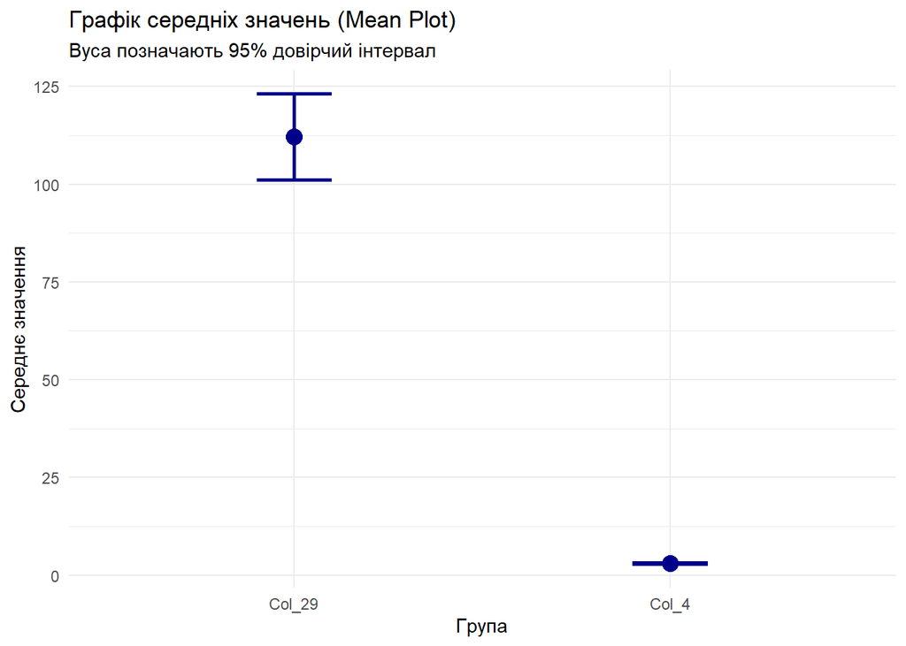

Інтервальні оцінки математичних сподівань

```r
# Розрахунок статистики для графіка
plot_data <- df_anova %>%
  group_by(Group) %>%
  summarise(
    Mean = mean(Value),
    SD = sd(Value),
    N = n(),
    SE = SD / sqrt(N),
    CI_Lower = Mean - qt(0.975, df = N-1) * SE,
    CI_Upper = Mean + qt(0.975, df = N-1) * SE
  )

# Графік 1: Інтервальні оцінки
ggplot(plot_data, aes(x = Group, y = Mean)) +
  geom_point(size = 4, color = "darkblue") +
  geom_errorbar(aes(ymin = CI_Lower, ymax = CI_Upper),
                width = 0.2, color = "darkblue", linewidth = 1) +
  labs(
    title = "Графік середніх значень (Mean Plot)",
    subtitle = "Вуса позначають 95% довірчий інтервал",
    x = "Група",
    y = "Середнє значення"
  ) +
  theme_minimal()
```

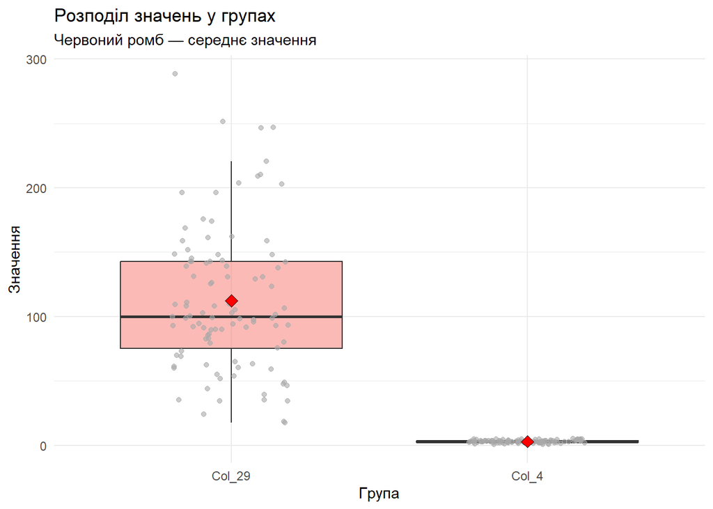

Діаграма розмаху з накладанням даних

```r
# Графік 2: Boxplot + Jitter
ggplot(df_anova, aes(x = Group, y = Value, fill = Group)) +
  geom_boxplot(alpha = 0.5, outlier.shape = NA) +
  geom_jitter(width = 0.2, alpha = 0.6, color = "darkgrey") +
  stat_summary(fun = mean, geom = "point", shape = 23, size = 3, fill = "red") +
  labs(
    title = "Розподіл значень у групах",
    subtitle = "Червоний ромб — середнє значення",
    x = "Група",
    y = "Значення"
  ) +
  theme_minimal() +
  theme(legend.position = "none")
```

## 4. Висновки

У ході лабораторної роботи було проведено дисперсійний аналіз для двох вибірок (`Col_4` та `Col_29`).

1. **Перевірка нормальності:** Тест Шапіро-Вілка показав, що p-значення для груп становлять 0.0021354 та 0.5492663.
   - *Інтерпретація:* Якщо $p > 0.05$, розподіл узгоджується з нормальним.
2. **Перевірка однорідності дисперсій:** Тест Бартлетта дав результат $p =$ < 0.001.
   - *Інтерпретація:* Якщо $p < 0.05$, дисперсії є неоднорідними.
3. **Результати порівняння:** ANOVA (F-тест) показав p-значення: < 0.001.

   **Загальний висновок:** Оскільки розраховане p-значення менше за рівень значущості $\alpha=0.05$, ми відхиляємо нульову гіпотезу. Між групами `Col_4` та `Col_29` існує статистично значуща відмінність у середніх значеннях.

## Перелік посилань

Сидоренко, В. М. 2023. *Методичні вказівки щодо виконання лабораторних і самостійної робіт з навчальної дисципліни «Ймовірнісно-статистичні методи інформаційних технологій» (Частина 2)*. Кременчук: Кременчуцький національний університет імені Михайла Остроградського.

Сидоренко, В. М., і Н. Г. Кирилаха. 2023. «Дидактико-методичні аспекти викладання теорії ймовірностей та математичної статистики студентам ІТ напряму». *Інженерні та освітні технології* 11 (3): 17–23. https://doi.org/10.32782/2307-9770.2023.11.03.02.

Сидоренко, В. М., С. А. Садовнича, і Є. В. Долударєва. 2022. «Оптимізація структури тестових завдань навчальних онлайн-курсів на основі ймовірнісної моделі». *Інженерні та освітні технології* 10 (2): 27–36. https://doi.org/10.30929/2307-9770.2022.10.02.03.